# MD07

2023-11-09

```r
library(tidyverse)
library(here)
library(moderndive)
theme_set(theme_minimal())

nobel_winners <- read_csv("C:/Users/黄诗谣/Desktop/Estella/DUKE/SOC223/nobel_winners.csv")
nobel_winners_flt <- nobel_winners %>%
  filter(category != "Peace") %>%
  mutate(is_us = if_else(birth_country == "United States of America", 1, 0))
```

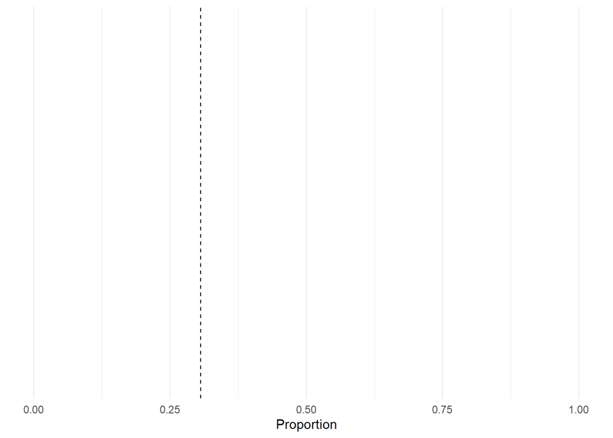

```r
true_prop <- nobel_winners_flt %>%
  group_by(is_us) %>%
  summarise(prop = n()/nrow(nobel_winners_flt))

ggplot() +
  coord_cartesian(xlim = c(0,1), ylim = c(0,1)) +
  geom_vline(xintercept = true_prop[2,2][[1]], linetype = "dashed")  +
  labs(x = "Proportion")
```

The true proportion of US-born Nobel Prize Winner is about 31%.

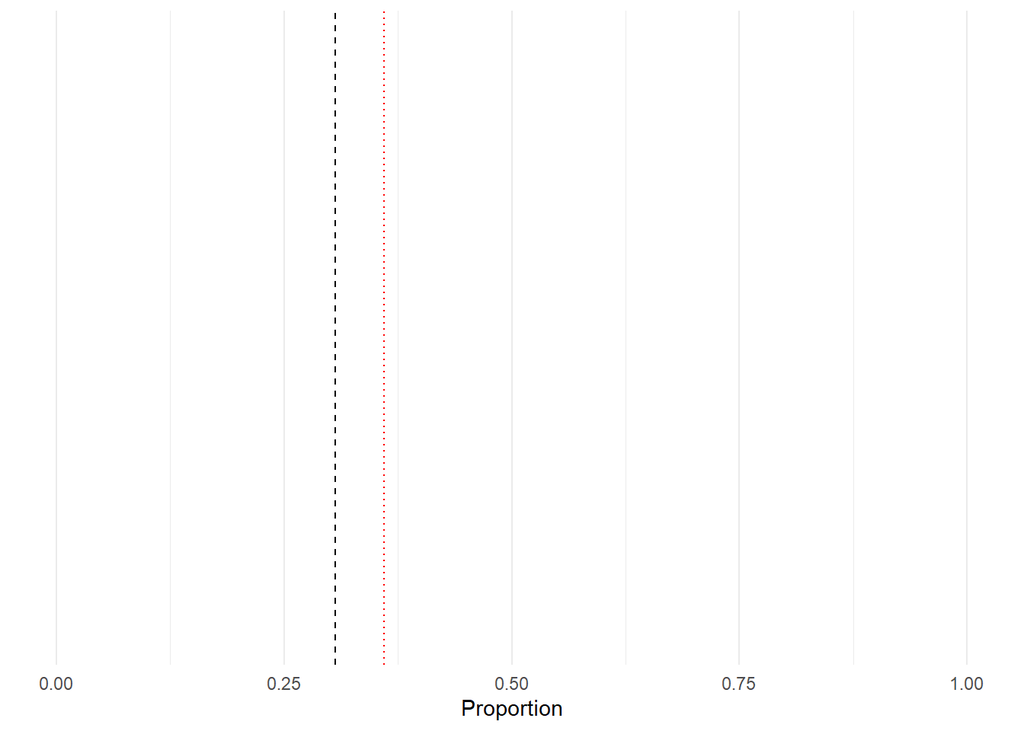

```r
# Random sample
our_sample <- sample_n(nobel_winners_flt,
                       size = 25,
                       replace = F)

sample_prop <- our_sample %>%
  group_by(is_us) %>%
  summarise(prop = n()/nrow(our_sample))

# How does our proportion look like?
ggplot() +
  coord_cartesian(xlim = c(0,1), ylim = c(0,1)) +
  geom_vline(xintercept = true_prop[2,2][[1]], linetype = "dashed")  +
  geom_vline(xintercept = sample_prop[2,2][[1]], linetype = "dotted", col = "red") +
  labs(x = "Proportion")
```

## Question1

What is the sampling frame? All the population, that is all the Nobel scientific Prize winners.

What does the black line represent? (hint: the word population is in the name). The black line represents the true proportion of US-born Nobel prize winners in the entire population of scientific Nobel prize winners.

What does the red line represent? It represents the proportion of US-born Nobel prize winners in the samples of 25 Nobel prize winners.

## Question2

```r
sample_results <- rep_sample_n(
  nobel_winners_flt,
  size = 25,
  reps = 50,
  replace = FALSE
)
```

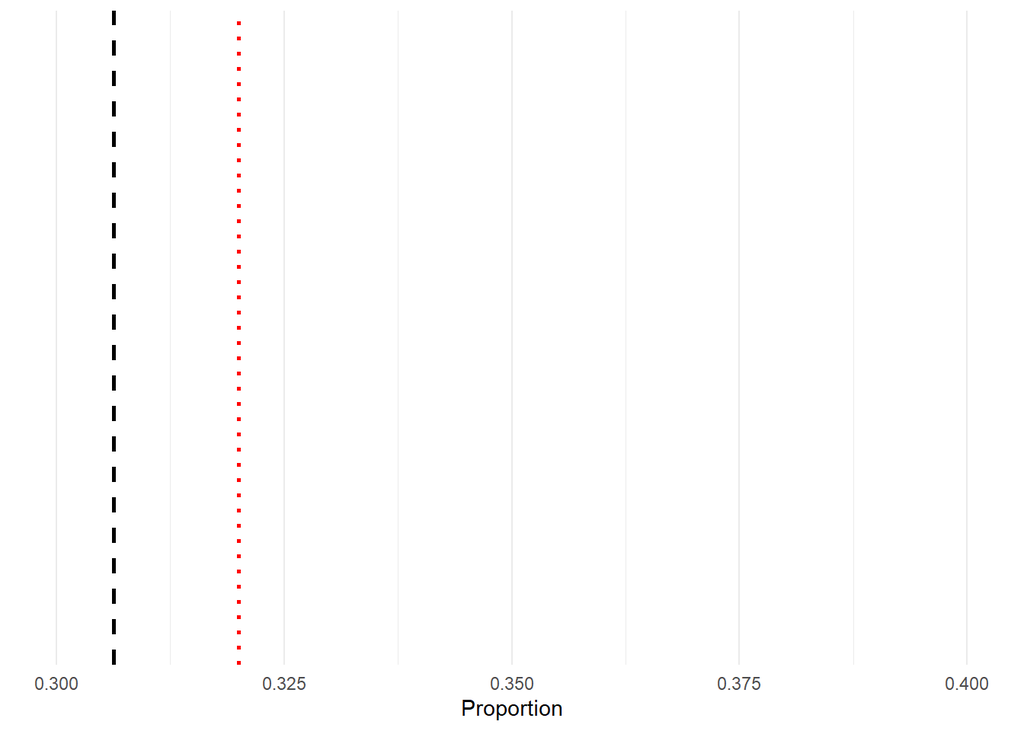

```r
# Calculate the true proportion
true_prop <- nobel_winners_flt %>%
  group_by(is_us) %>%
  summarise(prop = n()/nrow(nobel_winners_flt))

# Calculate the mean proportion of samples
mean_prop <- sample_results %>%
  group_by(replicate) %>%
  summarise(sample_prop = sum(is_us) / n())

# Plot the results
ggplot(sample_results) +
  coord_cartesian(xlim = c(0.3,0.4), ylim = c(0,1)) +
  geom_vline(xintercept = true_prop[2, 2][[1]], linetype = "dashed", color = "black", size = 1) +
  geom_vline(xintercept = mean(mean_prop$sample_prop), linetype = "dotted", color = "red", size = 1) +
  labs(x = "Proportion")
```

## Question3

```r
sample_results2 <- rep_sample_n(
  nobel_winners_flt,
  size = 100,
  reps = 50,
  replace = FALSE
)
```

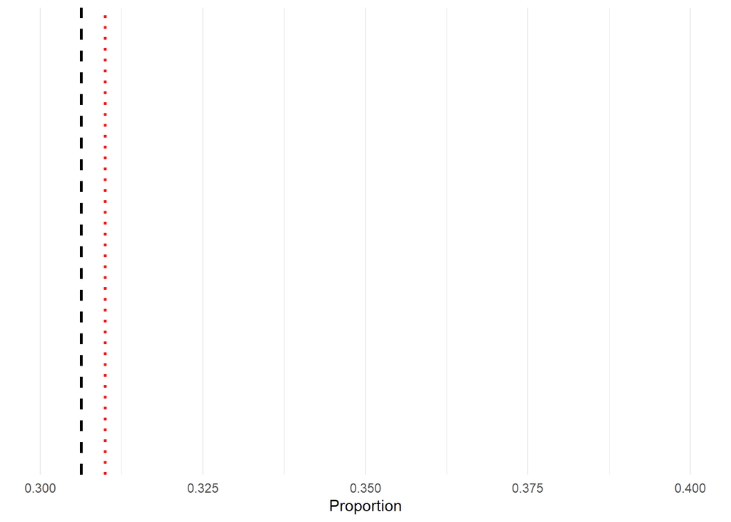

```r
# Calculate the true proportion
true_prop <- nobel_winners_flt %>%
  group_by(is_us) %>%
  summarise(prop = n()/nrow(nobel_winners_flt))

# Calculate the mean proportion of samples
mean_prop2 <- sample_results2 %>%
  group_by(replicate) %>%
  summarise(sample_prop2 = sum(is_us) / n())

# Plot the results
ggplot(sample_results2) +
  coord_cartesian(xlim = c(0.3,0.4), ylim = c(0,1)) +
  geom_vline(xintercept = true_prop[2, 2][[1]], linetype = "dashed", color = "black", size = 1) +
  geom_vline(xintercept = mean(mean_prop2$sample_prop2), linetype = "dotted", color = "red", size = 1) +
  labs(x = "Proportion")
```

The first distribution varies more. Because the second one provides larger sample size so that it could be closer to the true proportion.

## Question4

```r
std_dev_25 <- sd(mean_prop$sample_prop)

std_dev_25
```

```
## [1] 0.08590455
```

```r
std_dev_100 <- sd(mean_prop2$sample_prop2)

std_dev_100
```

```
## [1] 0.04840307
```

The first one has the larger standard deviation than the second one, means that the sample proportion with 25 samples is more spread out in terms of the mean proportion, while the second one with 100 samples is less spread out. It could support my argument.  
As the sample size increases, the variability in the estimates tends to decrease.

## Question5

```r
nobel_winners_flt_woman <- nobel_winners %>%
  filter(category != "Peace") %>%
  mutate(is_woman = if_else(gender == "Female", 1, 0))
```

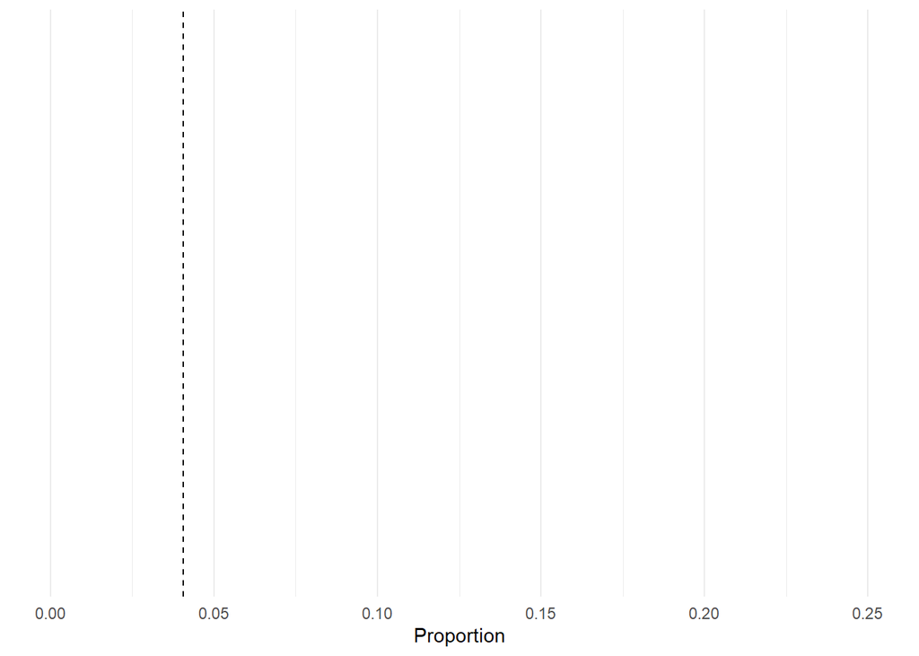

```r
true_prop_woman <- nobel_winners_flt_woman %>%
  group_by(is_woman) %>%
  summarise(prop = n() / nrow(nobel_winners_flt_woman))

ggplot() +
  coord_cartesian(xlim = c(0, 0.25), ylim = c(0, 1)) +
  geom_vline(xintercept = true_prop_woman[2, 2][[1]], linetype = "dashed") +
  labs(x = "Proportion")
```

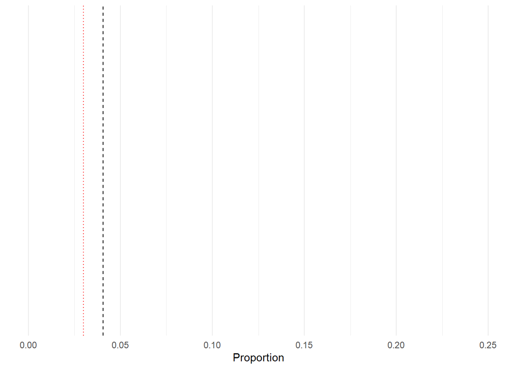

```r
random_sample <- sample_n(nobel_winners_flt_woman,
                       size = 100,
                       replace = F)

sample_prop_woman <- random_sample %>%
  group_by(is_woman) %>%
  summarise(prop = n()/nrow(random_sample))

ggplot() +
  coord_cartesian(xlim = c(0,0.25), ylim = c(0,1)) +
  geom_vline(xintercept = true_prop_woman[2,2][[1]], linetype = "dashed")  +
  geom_vline(xintercept = sample_prop_woman[2,2][[1]], linetype = "dotted", col = "red") +
  labs(x = "Proportion")
```

## Question6

The central limit theorem states that with the increase of the sample size, the distribution of the sample means will become approximately normal, regardless of the population distribution. If we take the sample sizes that are large enough and calculate their means, the means would follow a normal distribution.